# Simulations : Lesson on Distributions

# Discrete Distributions

## 1. Binomial Distribution

### Let’s generate random samples

$X \sim Binomial(20,0.4)$

```r
n = 20
p = 0.4
rbinom(1,n,p) #one binomial distributed random variable with (n,p)
```

```
## [1] 7
```

```r
rbinom(5,n,p) #five binomial distributed random variables with (n,p)
```

```
## [1] 10  6 12  7  9
```

### Compute and plot probability mass function

```r
dbinom(21,n,p)
```

```
## [1] 0
```

```r
dbinom(3.3,n,p) #Why wrong?
```

```
## [1] 0
```

Plot Probability Mass Function(pmf)

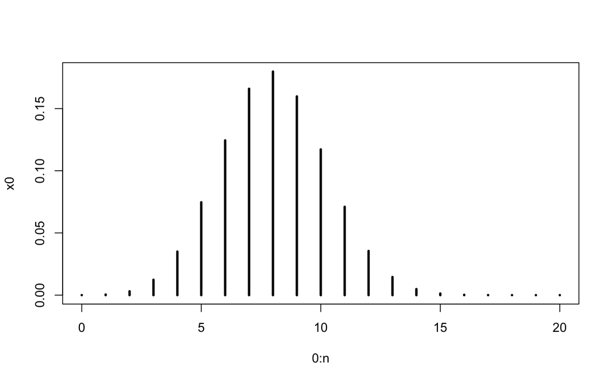

```r
x0 = dbinom(0:n,n,p) # probability at each point of x
plot(0:n,x0,type = 'h', lwd = 3)
```

*The sum of the pmf equals 1.*

```r
sum(dbinom(0:100,100,.3))
```

```
## [1] 1
```

### Compute pbinom() in terms of dbinom()

$P(X<5)?$

```r
pbinom(4,n,p) # cumulative probability values.
```

```
## [1] 0.05095195
```

```r
sum(dbinom(0:4,n,p))
```

```
## [1] 0.05095195
```

### Estimate dbinom() using rbinom()

$P(X=4)$

```r
dbinom(4,n,p) # Exact value
```

```
## [1] 0.03499079
```

```r
#by simulation
mean(rbinom(100000000,n,p) == 4)
```

```
## [1] 0.03498971
```

### Make a large random sample and plot a histogram.

*The histogram of the sample looks similar to, but is not identical to the histogram plot of the pmf in the previous picture.*

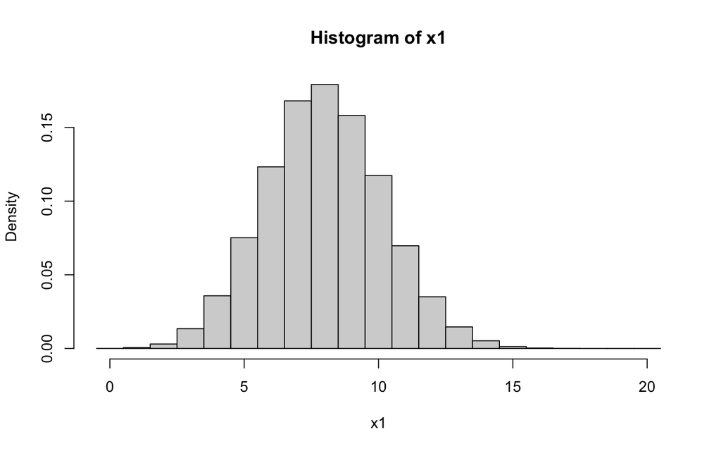

```r
x1 <- rbinom(100000,n,p)
hist(x1, prob = T, breaks = seq(-.5,20.5,by = 1))
```

### Cumulative distribution function.

$P(X\le5)$

```r
pbinom(5,n,p)
```

```
## [1] 0.125599
```

Plot the CDF.

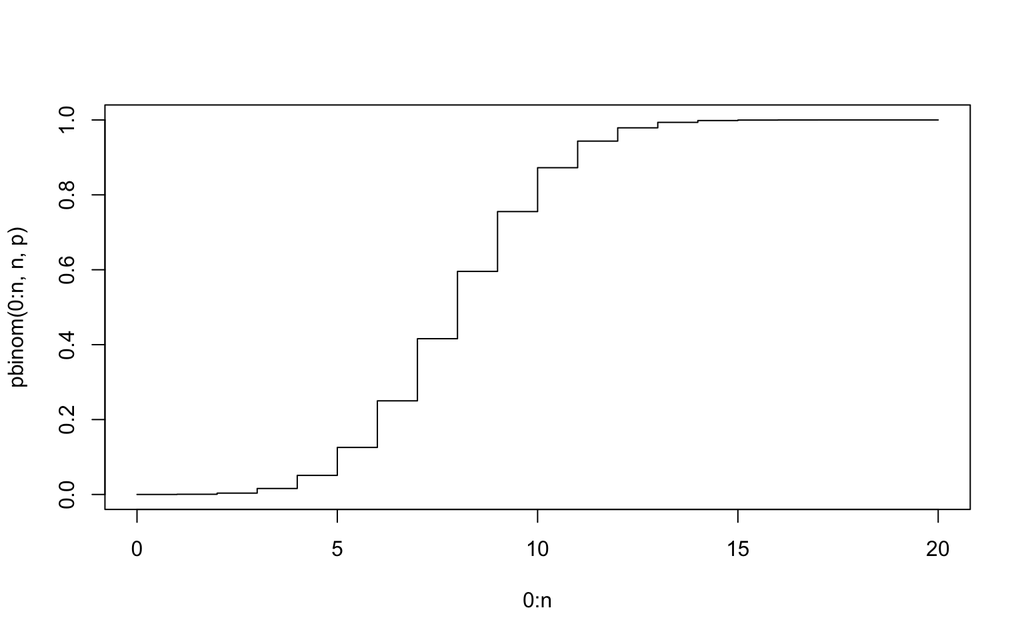

```r
plot(0:n,pbinom(0:n,n,p), type = 's')
```

### Guess the relation between the three values before computing them.

```r
pbinom(5,n,p)
```

```
## [1] 0.125599
```

```r
pbinom(5.1,n,p)
```

```
## [1] 0.125599
```

```r
pbinom(4.99,n,p)
```

```
## [1] 0.05095195
```

*Why?*

### Plot the cdf as a step function

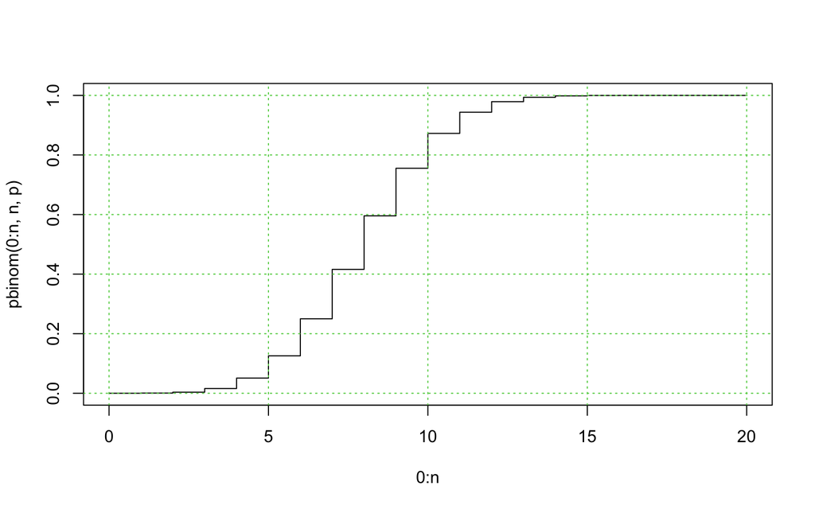

```r
plot(0:n,pbinom(0:n,n,p), type = 's')
grid(col = 3)
```

### Quantiles

Let’s explain the behavior.

```r
qbinom(.3,n,p)
```

```
## [1] 7
```

```r
qbinom(.35,n,p)
```

```
## [1] 7
```

```r
qbinom(.4722,n,p)
```

```
## [1] 8
```

```r
qbinom(.2799,n,p)
```

```
## [1] 7
```

```r
qbinom(pbinom(6,n,p),n,p)
```

```
## [1] 6
```

```r
pbinom(qbinom(.333,n,p),n,p)
```

```
## [1] 0.4158929
```

*Explain this! Why is this not 0.333?*

## 2. Geometric and Negative Binomial Distributions

### Plot the probability mass functions for a few cases

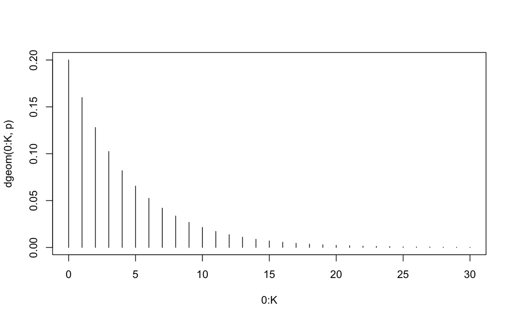

```r
n = 4
p = .2
K = 30
plot(0:K, dgeom(0:K,p), type = 'h')
```

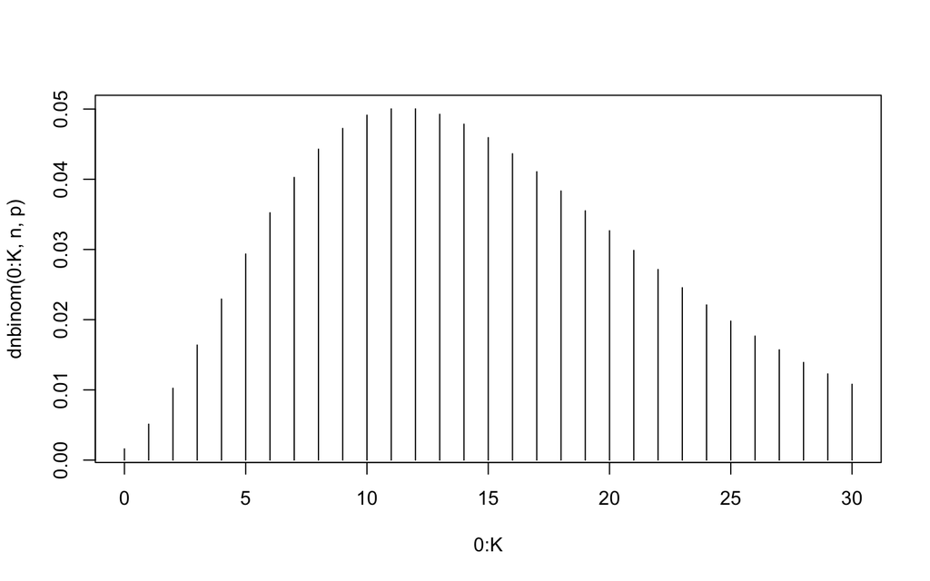

```r
plot(0:K, dnbinom(0:K,n,p), type = 'h')
```

## 3. Negative Binomial Distribution

### Example 1:

An oil company has a p = 0.20 chance of striking oil when drilling a well. What is the probability the company drills x = 7 wells to strike oil r = 3 times?

*If we are drilling 7 wells but strike oil only 3 times , that means our number of failures is 4 until 3 successes. Therefore, we need to find the probability*

$$P(X=4)$$

```r
r = 3
p = 0.20
n = 7 - r
# exact
dnbinom(x = n, size = r, prob = p)
```

```
## [1] 0.049152
```

Let’s try a simulation;

```r
# simulated
mean(rnbinom(n = 10000, size = r, prob = p) == n)
```

```
## [1] 0.0492
```

Cumulative Probability of X failed trials to achieve 3rd success.

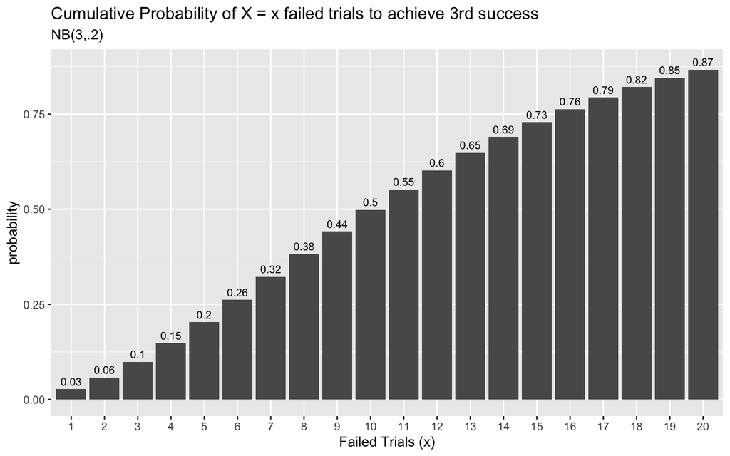

```r
library(dplyr)
library(ggplot2)

data.frame(x = 1:20,
           pmf = dnbinom(x = 1:20, size = r, prob = p),
           cdf = pnbinom(q = 1:20, size = r, prob = p, lower.tail = TRUE)) %>%
ggplot(aes(x = factor(x), y = cdf)) +
  geom_col() +
  geom_text(
    aes(label = round(cdf,2), y = cdf + 0.01),
    size = 3,
    vjust = 0
  ) +
  labs(title = "Cumulative Probability of X = x failed trials to achieve 3rd success",
       subtitle = "NB(3,.2)",
       x = "Failed Trials (x)",
       y = "probability")
```

## 4. Poisson Distribution

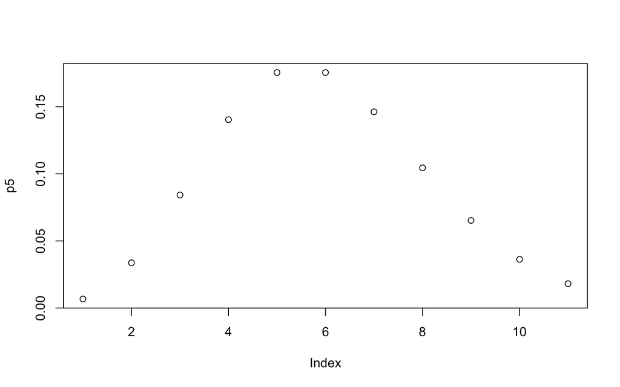

```r
p5=dpois(0:10,5)
p0.9=dpois(0:10,0.9)
plot(p5)
```

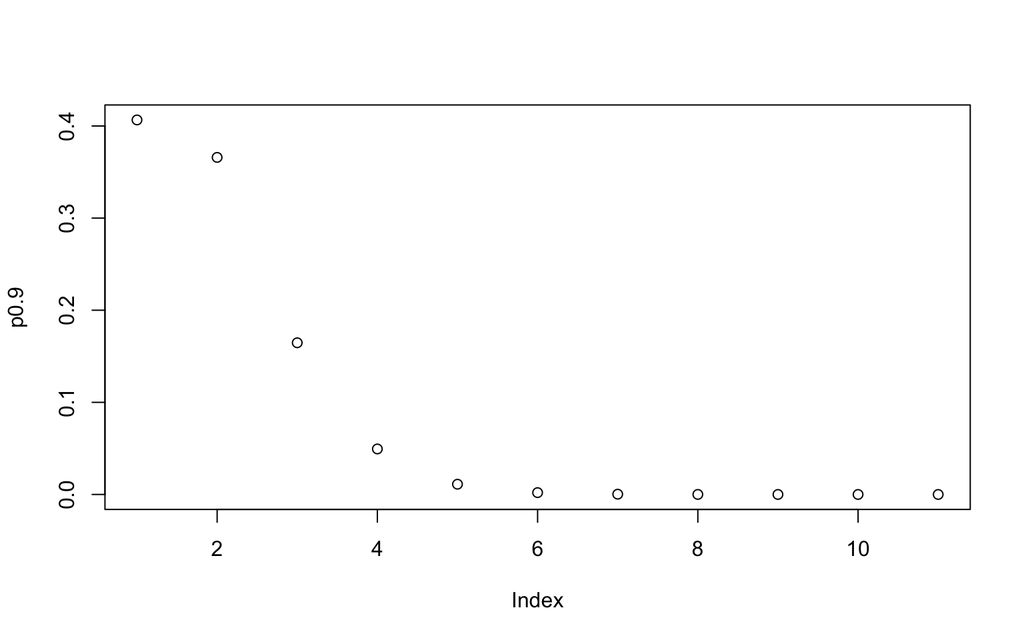

```r
plot(p0.9)
```

## Pmf and CDF of Poisson Distribution

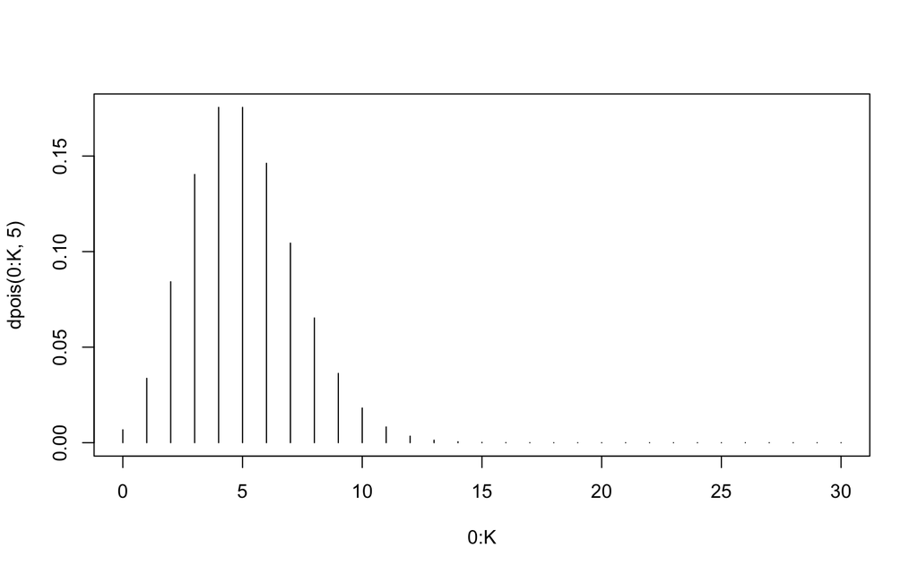

```r
plot(0:K, dpois(0:K, 5), type = 'h') #pmf
```

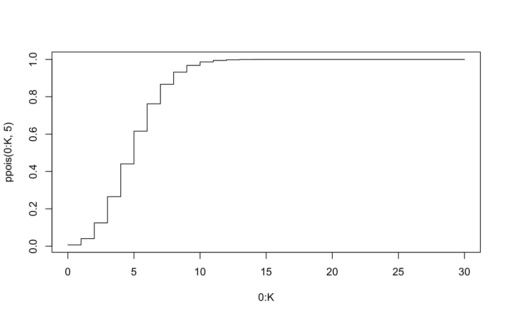

```r
plot(0:K, ppois(0:K, 5), type = 's') #cdf
```

## 5. Hypergeometric Distribution

#### Example 2:

What is the probability of selecting x = 14 red marbles from a sample of k = 20 taken from an urn containing m = 70 red marbles and n = 30 green marbles?

```r
x = 14 #number of successive draws
m = 70 #total number of successes inside the urn
n = 30 #total number of failures inside the urn
k = 20 #number of draws(trails)

dhyper(x = x, m = m, n = n, k = k)
```

```
## [1] 0.2140911
```

Plotting for different number of success draws

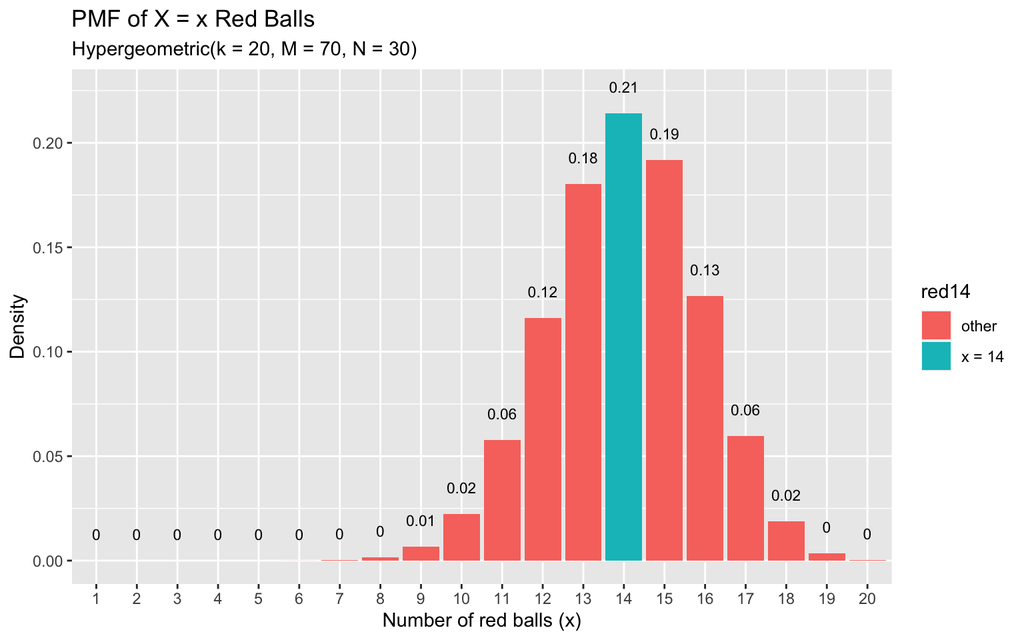

```r
library(ggplot2)
library(dplyr)
options(scipen = 999, digits = 2) # sig digits

density = dhyper(x = 1:20, m = m, n = n, k = k)

data.frame(red = 1:20, density) %>%
  mutate(red14 = ifelse(red == 14, "x = 14", "other")) %>%
ggplot(aes(x = factor(red), y = density, fill = red14)) +
  geom_col() +
  geom_text(
    aes(label = round(density,2), y = density + 0.01),
    size = 3,
    vjust = 0
  ) +
  labs(title = "PMF of X = x Red Balls",
       subtitle = "Hypergeometric(k = 20, M = 70, N = 30)",
       x = "Number of red balls (x)",
       y = "Density")
```

#### Example 3: Aces in a Five-Card Poker Hand

```r
x = seq(0,4) #possible number of aces
m = 4 # number of success elements in population = ace cards
n = 48  # number of failure elements in population=everything except ace cards
k = 5  # simple random sample size(five-card hand)

phyper(x,m,n,k)
```

```
## [1] 0.66 0.96 1.00 1.00 1.00
```

```r
dhyper(x,m,n,k)
```

```
## [1] 0.658842 0.299474 0.039930 0.001736 0.000018
```

Those are the chances of all the different possible numbers of aces in a poker hand. They are rather hard to read, so let’s try rounding them.

```r
round(phyper(x,m,n,k), 3)
```

```
## [1] 0.66 0.96 1.00 1.00 1.00
```

The histogram of the distribution can be drawn using Plot.

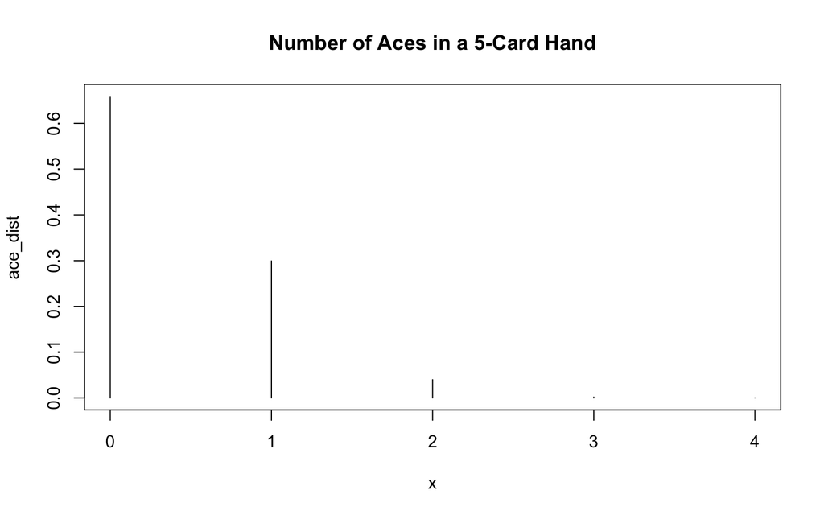

```r
ace_dist = dhyper(x,m,n,k)
plot(x,ace_dist, main ='Number of Aces in a 5-Card Hand',type='h')
```

# Continuous Distributions

## 1. Exponential Distibution

Multiple Exponential Distribution Plots:

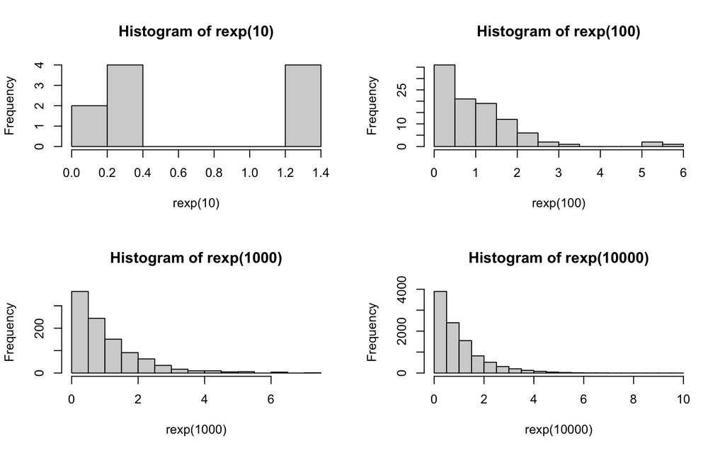

```r
par(mfrow=c(2,2))

hist(rexp(10))
hist(rexp(100))
hist(rexp(1000))
hist(rexp(10000))
```

```r
library(ggplot2)

x_lower <- 0
x_upper <- 5

max_height2 <- max(dexp(x_lower:x_upper, rate = 1, log = FALSE),
                   dexp(x_lower:x_upper, rate = 2,  log = FALSE),
                   dexp(x_lower:x_upper, rate = 0.5, log = FALSE))

max_height2
```

```
## [1] 2
```

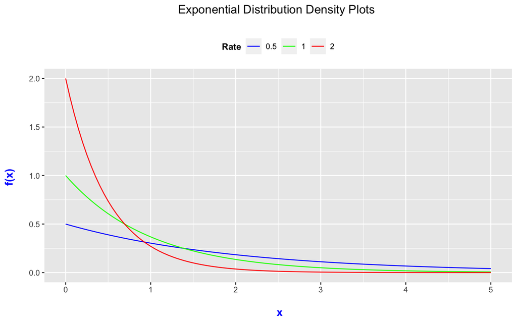

```r
ggplot(data.frame(x = c(x_lower, x_upper)), aes(x = x)) + xlim(x_lower, x_upper) +
  ylim(0, max_height2) +
  stat_function(fun = dexp, args = list(rate = 0.5), aes(colour = "0.5")) +
  stat_function(fun = dexp, args = list(rate = 1), aes(colour = "1")) +
  stat_function(fun = dexp, args = list(rate = 2), aes(colour = "2")) +
  scale_color_manual("Rate", values = c("blue", "green", "red")) +
  labs(x = "\n x", y = "f(x) \n",
       title = "Exponential Distribution Density Plots \n") +
  theme(plot.title = element_text(hjust = 0.5),
        axis.title.x = element_text(face="bold", colour="blue", size = 12),
        axis.title.y = element_text(face="bold", colour="blue", size = 12),
        legend.title = element_text(face="bold", size = 10),
        legend.position = "top")
```

```r
# References:
# https://stackoverflow.com/questions/31792634/adding-legend-to-ggplot2-with-multiple-lines-on-plot
# https://stackoverflow.com/questions/19950219/using-legend-with-stat-function-in-ggplot2
```

## 2. Normal Distribution

### Standard Deviation vs Variablity

```r
set.seed(37)
sample1 <- rnorm(5, mean=10, sd=10)
sample2 <- rnorm(5, mean=10, sd=0.1)


sample1
```

```
## [1] 11.2 13.8 15.8  7.1  1.7
```

```r
sample2
```

```
## [1] 10 10 10 10 10
```

```r
round(sample1)
```

```
## [1] 11 14 16  7  2
```

```r
round(sample2)
```

```
## [1] 10 10 10 10 10
```

Less standard deviation means less variability in data.

Theoretical density plot for a standard normal distribution as follows

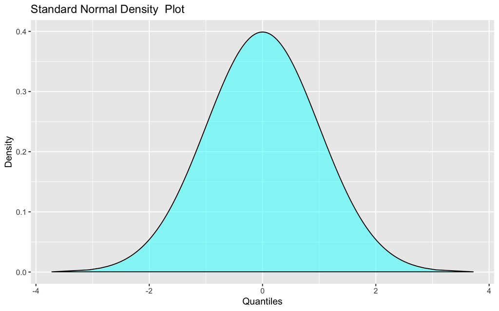

```r
cumProb <- seq(.0001,.9999,length = 1000)
quants <- qnorm(cumProb, mean = 0, sd = 1) #standard normal distribution
den <- dnorm(quants, mean = 0, sd = 1)

tibi1 =tibble(cumProb,quants,den)

ggplot(tibi1, aes(x = quants,y = den)) +
  geom_polygon(fill = 'cyan',color = 'black',size = .5, alpha=.5) +
  labs(x = 'Quantiles',y = 'Density',
     title='Standard Normal Density  Plot')
```

Cumulative Probability plot for a standard normal distribution

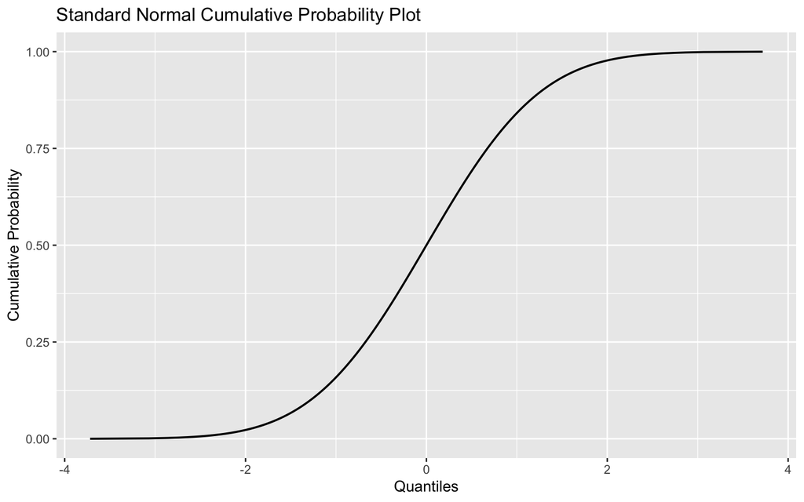

```r
ggplot(tibi1,aes(x = quants,y = cumProb))+
  geom_line(size=.7) +
  labs(x = 'Quantiles',y = 'Cumulative Probability',
     title = 'Standard Normal Cumulative Probability Plot')
```

Using rnorm() to create histograms: Let’s generate three different vectors of random numbers from a normal distribution

```r
set.seed(33)
n10 <- rnorm(10, mean = 70, sd = 5)
n100 <- rnorm(100, mean = 70, sd = 5)
n10000 <-  rnorm(10000, mean = 70, sd = 5)

# Let's just look at one of the vectors
n10
```

```
##  [1] 69 70 75 69 59 72 66 74 74 65
```

Which histogram do you think will be most centered around the true mean of 70??

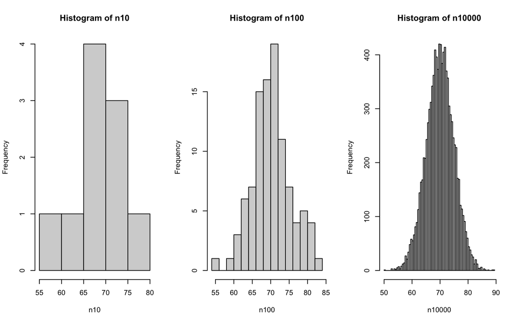

```r
par(mfrow=c(1,3))

# The breaks argument specifies how many bars are in the histogram
hist(n10, breaks = 5)
hist(n100, breaks = 20)
hist(n10000, breaks = 100)
```

## 3. Gamma Distribution

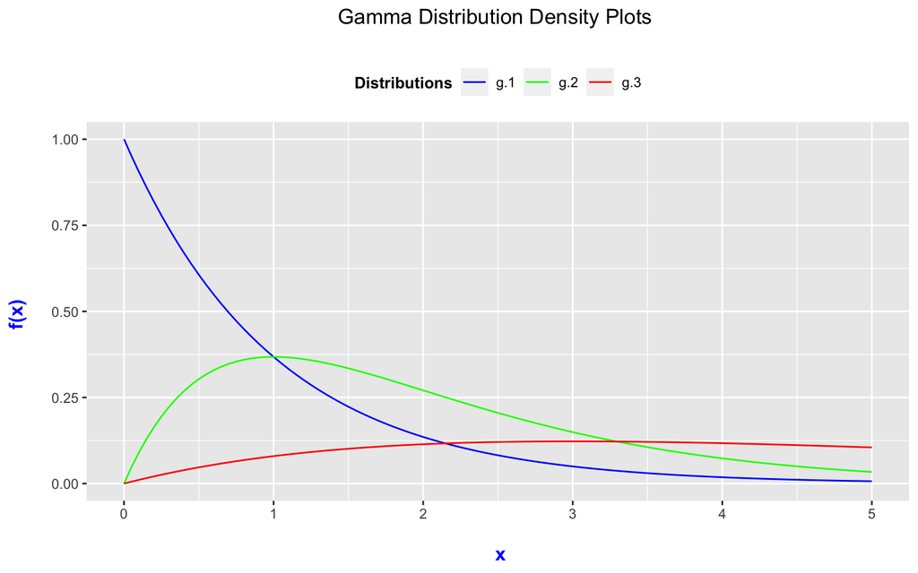

```r
library(ggplot2)

x_lower <- 0
x_upper <- 5

max_height2 <- max(dgamma(x_lower:x_upper, shape = 1, scale = 1),
                   dgamma(x_lower:x_upper, shape = 2, scale = 1),
                  dgamma(x_lower:x_upper, shape = 2, scale = 3))


ggplot(data.frame(x = c(x_lower, x_upper)), aes(x = x)) + xlim(x_lower, x_upper) +
  ylim(0, max_height2) + #g.1
  stat_function(fun = dgamma, args = list(shape = 1, scale = 1), aes(colour = "g.1")) +
  stat_function(fun = dgamma, args = list(shape = 2, scale = 1), aes(colour = "g.2")) + #g.2
  stat_function(fun = dgamma, args = list(shape = 2, scale = 3), aes(colour = "g.3")) + #g.3
  scale_color_manual("Distributions", values = c("blue", "green", "red")) +
  labs(x = "\n x", y = "f(x) \n",
       title = "Gamma Distribution Density Plots \n") +
  theme(plot.title = element_text(hjust = 0.5),
        axis.title.x = element_text(face="bold", colour="blue", size = 12),
        axis.title.y = element_text(face="bold", colour="blue", size = 12),
        legend.title = element_text(face="bold", size = 10),
        legend.position = "top")
```

#### Example 4:

On average, someone sends a money order once per 15 minutes. What is the probability someone sends 10 money orders in less than 3 hours?

$X\sim Gamma(alpha=10,beta=15/60)$ $P(X<3)?$

```r
alpha = 10
beta = 15 / 60
x = 3
# exact
pgamma(q = x, shape = alpha, scale = beta)
```

```
## [1] 0.76
```

```r
# simulated
mean(rgamma(n = 10000, shape = alpha, scale = beta) <= x)
```

```
## [1] 0.76
```

### Expected Values

#### Example 5: Binomial distribution

```r
n = 30
p = .4

sum((0:n)*dbinom(0:n,n,p))
```

```
## [1] 12
```

```r
sum((0:n)*dbinom(0:n,n,p)) -12  # determine how close this is to the exact value
```

```
## [1] -0.0000000000000018
```

```r
                                # the difference is due to round off error
mean(rbinom(10000,n,p))
```

```
## [1] 12
```

```r
n*p
```

```
## [1] 12
```

#### Example 6: Poisson distribution

```r
lambda = 4
n = 20 # truncate the infinite sum
sum((0:n)*dpois(0:n, lambda))
```

```
## [1] 4
```

```r
sum((0:n)*dpois(0:n, lambda)) - 4 # determine how close this is to the exact value
```

```
## [1] -0.000000041
```

```r
                                  #  the difference is mainly due to truncation error
mean(rpois(10000,lambda))
```

```
## [1] 4
```